# Analyses for one species

Andrew Edwards

This vignette shows how to extract and analyse the data for a single species. Since the extraction from the GFBio database only works for users on the Pacific Biological Station network that have permission to access the database, an example data set for Yelloweye Rockfish is included in the package.

Quick version – there is a wrapper function, `iphc_get_calc_plot_full(sp)` that does all the extraction, calculations, and plotting for a given species. This vignette shows the details to aid understanding. So for a quick look to see if the data look potentially useful, just do, for example, `iphc_get_calc_plot_full("bocaccio")`. If the resulting series looks useful then repeat this vignette for your species of interest to understand the results.

Even quicker version for a quick look at results – all the most recent data are now downloaded, analysed and the results shown (though not saved anywhere due to size). See the All Species link on the main [README](https://github.com/pbs-assess/gfiphc).

```r
library(gfiphc)
library(dplyr)    # To print tibble properly
```

## Data for species of interest

Define common species name:

```r
sp <- "yelloweye rockfish"
sp_short_name <- "Yelloweye"  # short name for legends
```

It is worth checking that your species of interest is not in this list of IPHC species names that are in the IPHC data but not automatically extracted by this package (because the synopsis report did not look at it, or it is a general term such as `Eelpout`):

```r
check_iphc_spp_name()
```

```
#>  [1] "Unidentified Shark"          "Unident. Rockfish"
#>  [3] "unident. thornyhead (Idiot)" "Grenadier (Rattails)"
#>  [5] "Miscellaneous Shark"         "Eelpout"
#>  [7] "unident. Roundfish"          "unident. Sculpin"
#>  [9] "Unident. Flatfish"           "Greenland Turbot"
#> [11] "unident. Hagfish"            "Starry Skate"
#> [13] "Black Skate"                 "Brittle Star"
#> [15] "Glass Sponge"                "Basketstar"
#> [17] "Blackspotted Rockfish"
```

If you want to look for one of these species, then the common name and IPHC name need to be added to `inst/extdata/iphc-spp-names.csv`. There are also some non-groundfish species names, such as crabs, starfish and a Steller Sea Lion (!) that get automatically ignored in `check_iphc_spp_name()` – type `check_iphc_spp_name` to see the function and the embedded list if you need to check.

Someone at PBS has to run the next chunk of code to extract data from the GFBio database and send the external collaborator the resulting .rds file, which will have the format `species-name.rds`, e.g. `longnose-skate.rds`. As an example, the data for Yelloweye Rockfish have been extracted and included as data in the package. Hence this chunk is not evaluated for this vignette:

```r
# This chunk will only work within PBS
cache_pbs_data_iphc(sp)
                                       # That creates species-name. [This is
                                       #  what gfsynopsis::get_data_iphc() calls,
                                       #  via gfsynopsis::get_data() in
                                       #  report/make.R of gfsynopsis
                                       #  repo.]. Note the argument can be a
                                       #  vector species names to save multiple species.
```

Once an external person has the `species-name.rds` file, the two lines in the next chunk can be appropriately commented/uncommented to load the data. For this vignette we will use the Yelloweye Rockfish data included in the package:

```r
# Comment this out to analyse non-yelloweye data:
sp_set_counts <- yelloweye_rockfish

# Uncomment this to analyse non-yelloweye data:
# sp_set_counts <- readRDS(paste0(gsub(" ", "-", sp), ".rds"))
```

## Details for all skates and stations, and hooks returned with bait

Other data sets are already built into the gfiphc package, the main ones are given here for reference.

Locations and effective skate values of stations for the 1995 survey:

```r
setData1995
```

```
#> # A tibble: 120 × 5
#>      lat   lon station effSkate usable
#>    <dbl> <dbl> <chr>      <dbl> <chr>
#>  1  52.4 -129. 10D         5.02 Y
#>  2  52.4 -130. 10G         4.92 Y
#>  3  52.3 -130  10GC        4.97 Y
#>  4  52.4 -130. 10I         4.82 Y
#>  5  52.4 -131. 10L         4.82 Y
#>  6  52.3 -131. 10LC        4.97 Y
#>  7  52.6 -130  11E         4.97 Y
#>  8  52.6 -130. 11H         4.97 Y
#>  9  52.7 -131. 11HC        4.97 Y
#> 10  52.6 -131. 11J         4.92 Y
#> # … with 110 more rows
```

Counts of each species at each station in 1995:

```r
countData1995
```

```
#> # A tibble: 1,235 × 4
#>     year station spNameIPHC           specCount
#>    <int> <chr>   <chr>                    <int>
#>  1  1995 10D     Pacific Halibut             38
#>  2  1995 10D     Lingcod                      6
#>  3  1995 10D     Spiny Dogfish               89
#>  4  1995 10D     unident. Skate               1
#>  5  1995 10D     Spotted Ratfish              2
#>  6  1995 10D     Unidentified Shark           1
#>  7  1995 10D     unident. Starfish            2
#>  8  1995 10D     Quillback Rockfish           4
#>  9  1995 10D     Yelloweye Rockfish          35
#> 10  1995 10D     Missing Hook/Gangion       273
#> # … with 1,225 more rows
```

Catches at each station from 1996 to 2002:

```r
data1996to2002
```

```
#> # A tibble: 8,569 × 13
#>     year station   set   lon   lat depthAvge spCodeIPHC spNameI…¹ catch…² skates
#>    <dbl>   <dbl> <dbl> <dbl> <dbl>     <dbl>      <dbl> <chr>       <dbl>  <dbl>
#>  1  1996   10011    15  -130  51.4       247          1 Pacific …      15      6
#>  2  1996   10011    15  -130  51.4       247          2 Arrowtoo…       5      6
#>  3  1996   10011    15  -130  51.4       247         27 Sablefis…      67      6
#>  4  1996   10011    15  -130  51.4       247         30 unident.…      15      6
#>  5  1996   10011    15  -130  51.4       247         31 Rougheye…      62      6
#>  6  1996   10011    15  -130  51.4       247         45 Unident.…       8      6
#>  7  1996   10011    15  -130  51.4       247         54 Spiny Do…       2      6
#>  8  1996   10011    15  -130  51.4       247         55 unident.…       4      6
#>  9  1996   10011    15  -130  51.4       247         57 Canary R…       1      6
#> 10  1996   10011    15  -130  51.4       247         90 Redbande…       2      6
#> # … with 8,559 more rows, 3 more variables: hooksObserved <dbl>, usable <chr>,
#> #   E_it <dbl>, and abbreviated variable names ¹spNameIPHC, ²catchCount
```

Station details for 2013 survey:

```r
setData2013
```

```
#> # A tibble: 170 × 8
#>     year station   lat   lon avgDepth effSkateIPHC E_it20 usable
#>    <int> <chr>   <dbl> <dbl>    <int>        <dbl>  <dbl> <chr>
#>  1  2013 2001     48.3 -126.       76         5.96   1.19 Y
#>  2  2013 2002     48.3 -126.       93         5.90   1.19 Y
#>  3  2013 2003     48.5 -125.       79         5.90   1.19 Y
#>  4  2013 2004     48.5 -126.       56         5.96   1.20 Y
#>  5  2013 2005     48.5 -126.       58         6.02   1.20 Y
#>  6  2013 2006     48.5 -126.      110         5.78   1.16 Y
#>  7  2013 2007     48.7 -125.       35         5.96   1.20 Y
#>  8  2013 2008     48.7 -125.       35         5.90   1.20 Y
#>  9  2013 2009     48.7 -126.       67         5.90   1.19 Y
#> 10  2013 2010     48.7 -126.       41         5.96   1.20 Y
#> # … with 160 more rows
```

Station details for 2020 survey:

```r
setData2020
```

```
#> # A tibble: 197 × 11
#>     year station   lat   lon avgDepth effSkateIPHC E_it20 usable stand…¹ hooks…²
#>    <int> <chr>   <dbl> <dbl>    <int>        <dbl>  <dbl> <chr>  <fct>     <dbl>
#>  1  2020 2044     50.8 -129.       50         7.95   1.61 Y      Y           792
#>  2  2020 2045     50.8 -129.       68         7.95   1.61 Y      Y           792
#>  3  2020 2046     51.0 -128.       53         7.95   1.61 Y      Y           792
#>  4  2020 2047     51.0 -129.       39         7.95   1.61 Y      Y           792
#>  5  2020 2048     51.0 -129.       47         7.95   1.61 Y      Y           792
#>  6  2020 2049     51.0 -129.       86         7.95   1.61 Y      Y           792
#>  7  2020 2050     51   -130.      131         7.95   1.61 Y      Y           792
#>  8  2020 2051     51.2 -128.       58         7.95   1.61 Y      Y           792
#>  9  2020 2052     51.2 -128.      106         7.95   1.61 Y      Y           792
#> 10  2020 2053     51.2 -129.       56         7.95   1.61 Y      Y           792
#> # … with 187 more rows, 1 more variable: hooksObs <dbl>, and abbreviated
#> #   variable names ¹standard, ²hooksRetr
```

Station details for 2021 survey:

```r
setData2021
```

```
#> # A tibble: 232 × 11
#>     year station   lat   lon avgDepth effSkateIPHC E_it20 usable stand…¹ hooks…²
#>    <int> <chr>   <dbl> <dbl>    <int>        <dbl>  <dbl> <chr>  <fct>     <dbl>
#>  1  2021 2002     48.3 -126.      195         3.98  0.804 Y      Y           396
#>  2  2021 2010     48.7 -126.       40         3.98  0.804 Y      Y           396
#>  3  2021 2011     48.7 -126.       77         3.98  0.804 Y      Y           396
#>  4  2021 2012     48.8 -126.       24         3.98  0.804 Y      Y           396
#>  5  2021 2014     48.8 -126.       56         3.98  0.804 Y      Y           396
#>  6  2021 2016     49.0 -126.       37         3.93  0.792 Y      Y           392
#>  7  2021 2017     49.0 -126.       75         3.98  0.804 Y      Y           396
#>  8  2021 2018     49.0 -127.      127         3.93  0.802 Y      Y           392
#>  9  2021 2019     49.2 -126.       47         3.98  0.804 Y      Y           396
#> 10  2021 2020     49.2 -127.       68         3.98  0.804 Y      Y           396
#> # … with 222 more rows, 1 more variable: hooksObs <dbl>, and abbreviated
#> #   variable names ¹standard, ²hooksRetr
```

Station details for 2022 survey:

```r
setData2022
```

```
#> # A tibble: 174 × 11
#>     year station   lat   lon avgDepth effSkateIPHC E_it20 usable stand…¹ hooks…²
#>    <int> <chr>   <dbl> <dbl>    <int>        <dbl>  <dbl> <chr>  <fct>     <dbl>
#>  1  2022 2001     48.3 -126.       77         8.03   1.61 Y      Y           800
#>  2  2022 2003     48.5 -125.       74         8.03   1.61 Y      Y           800
#>  3  2022 2004     48.5 -126.       55         8.03   1.61 Y      Y           800
#>  4  2022 2005     48.5 -126.       58         7.95   1.61 Y      Y           792
#>  5  2022 2006     48.5 -126.      107         8.03   1.61 Y      Y           800
#>  6  2022 2007     48.7 -125.       35         8.03   1.61 Y      Y           800
#>  7  2022 2008     48.7 -125.       34         8.03   1.61 Y      Y           800
#>  8  2022 2009     48.7 -126.       55         7.95   1.61 Y      Y           792
#>  9  2022 2013     48.8 -126.       33         8.03   1.61 Y      Y           800
#> 10  2022 2015     48.8 -126.       96         8.03   1.61 Y      Y           800
#> # … with 164 more rows, 1 more variable: hooksObs <dbl>, and abbreviated
#> #   variable names ¹standard, ²hooksRetr
```

Station details regarding expansion stations from 2018 (and some later years):

```r
setDataExpansion
```

```
#> # A tibble: 317 × 7
#>    station   lat   lon rca   mpa   mpa_name standard
#>    <chr>   <dbl> <dbl> <fct> <fct> <fct>    <fct>
#>  1 2336     53.9 -490. N     N     <NA>     N
#>  2 2337     54.8 -490. N     N     <NA>     N
#>  3 2338     51.5 -488. N     N     <NA>     N
#>  4 2339     50.9 -486. N     N     <NA>     N
#>  5 2340     50.6 -486. N     N     <NA>     N
#>  6 2341     49.6 -486. N     N     <NA>     N
#>  7 2342     50.5 -488. N     N     <NA>     N
#>  8 2001     48.3 -126. N     N     <NA>     Y
#>  9 2002     48.3 -126. N     N     <NA>     Y
#> 10 2003     48.5 -125. N     N     <NA>     Y
#> # … with 307 more rows
```

The following data sets are extracted from GFBio but extracted at PBS and then included in the package (using `data-raw/sets-skates-hooks-yelloweye.R`), which will be run each year to update the data objects.

Station details from GFBio for years not mentioned above:

```r
sets_other_years
```

```
#> # A tibble: 2,841 × 15
#>     year tripID  setID station setInTrip  long   lat obsHooksP…¹ deplH…² skate…³
#>    <int>  <dbl>  <dbl> <chr>       <dbl> <dbl> <dbl>       <dbl>   <int>   <dbl>
#>  1  2003  52040 334550 2007            1 -125.  48.7         795     800       8
#>  2  2003  52040 334551 2008            2 -125.  48.7         781     800       8
#>  3  2003  52040 334552 2003            3 -125.  48.5         796     800       8
#>  4  2003  52040 334553 2004            4 -126.  48.5         797     800       8
#>  5  2003  52040 334554 2001            5 -126.  48.3         800     800       8
#>  6  2003  52040 334555 2002            6 -126.  48.3         798     800       8
#>  7  2003  52040 334556 2006            7 -126.  48.5         802     800       8
#>  8  2003  52040 334557 2005            8 -126.  48.5         785     800       8
#>  9  2003  52040 334558 2012            9 -126.  48.8         805     800       8
#> 10  2003  52040 334559 2009           10 -126.  48.7         806     800       8
#> # … with 2,831 more rows, 5 more variables: effSkateIPHC <dbl>,
#> #   iphcUsabilityCode <dbl>, iphcUsabilityDesc <chr>, usable <chr>,
#> #   standard <fct>, and abbreviated variable names ¹obsHooksPerSet,
#> #   ²deplHooksPerSet, ³skatesCount
```

Skate-level details from GFBio (though such data are not available for years for which data are only available at the set-by-set level):

```r
skates_other_years
```

```
#> # A tibble: 18,672 × 16
#>     year tripID   set  setID skate skateID  bait deplH…¹ obsHo…² first…³ lastH…⁴
#>    <int>  <dbl> <dbl>  <dbl> <dbl>   <dbl> <dbl>   <int>   <int>   <dbl>   <int>
#>  1  2003  52040     1 334550     1  334634   110      99      99       1      99
#>  2  2003  52040     1 334550     2  334635   110     102     102     100     201
#>  3  2003  52040     1 334550     3  334636   110      99      99     202     300
#>  4  2003  52040     1 334550     4  334637   110      96      96     301     396
#>  5  2003  52040     1 334550     5  334638   110      99      99     397     495
#>  6  2003  52040     1 334550     6  334639   110      97      97     496     592
#>  7  2003  52040     1 334550     7  334640   110     103     103     593     695
#>  8  2003  52040     1 334550     8  334641   110     100     100     696     795
#>  9  2003  52040     2 334551     1  334642   110      91      91       1      91
#> 10  2003  52040     2 334551     2  334643   110      98      98      92     189
#> # … with 18,662 more rows, 5 more variables: hook20 <dbl>,
#> #   chumDeplHooksPerSkate <int>, chumObsHooksPerSkate <int>,
#> #   obsHooksPerSkate20 <dbl>, chumObsHooksPerSkate20 <dbl>, and abbreviated
#> #   variable names ¹deplHooksPerSkate, ²obsHooksPerSkate, ³firstHook, ⁴lastHook
```

Counts of hooks returned with bait on them, for each set, for all years (note it is a list containing one tibble):

```r
hooks_with_bait
```

```
#> $set_counts
#> # A tibble: 4,745 × 12
#>     year station   lat   lon  E_it  N_it   C_it E_it20 N_it20 C_it20 usable
#>    <dbl> <chr>   <dbl> <dbl> <dbl> <dbl>  <dbl>  <dbl>  <dbl>  <dbl> <chr>
#>  1  1995 10D      52.4 -129.  5.02     0  0         NA     NA     NA Y
#>  2  1995 10G      52.4 -130.  4.92    54 11.0       NA     NA     NA Y
#>  3  1995 10GC     52.3 -130   4.97    27  5.43      NA     NA     NA Y
#>  4  1995 10I      52.4 -130.  4.82     6  1.25      NA     NA     NA Y
#>  5  1995 10L      52.4 -131.  4.82    44  9.13      NA     NA     NA Y
#>  6  1995 10LC     52.3 -131.  4.97   278 55.9       NA     NA     NA Y
#>  7  1995 11E      52.6 -130   4.97     3  0.604     NA     NA     NA Y
#>  8  1995 11H      52.6 -130.  4.97   175 35.2       NA     NA     NA Y
#>  9  1995 11HC     52.7 -131.  4.97     7  1.41      NA     NA     NA Y
#> 10  1995 11J      52.6 -131.  4.92    15  3.05      NA     NA     NA Y
#> # … with 4,735 more rows, and 1 more variable: standard <fct>
```

Counts of Yelloweye Rockfish on each set for all years (note it is a list containing one tibble):

```r
yelloweye_rockfish
```

```
#> $set_counts
#> # A tibble: 4,745 × 12
#>     year station   lat   lon  E_it  N_it  C_it E_it20 N_it20 C_it20 usable
#>    <dbl> <chr>   <dbl> <dbl> <dbl> <dbl> <dbl>  <dbl>  <dbl>  <dbl> <chr>
#>  1  1995 10D      52.4 -129.  5.02    35  6.97     NA     NA     NA Y
#>  2  1995 10G      52.4 -130.  4.92     0  0        NA     NA     NA Y
#>  3  1995 10GC     52.3 -130   4.97     0  0        NA     NA     NA Y
#>  4  1995 10I      52.4 -130.  4.82     0  0        NA     NA     NA Y
#>  5  1995 10L      52.4 -131.  4.82     0  0        NA     NA     NA Y
#>  6  1995 10LC     52.3 -131.  4.97     0  0        NA     NA     NA Y
#>  7  1995 11E      52.6 -130   4.97     0  0        NA     NA     NA Y
#>  8  1995 11H      52.6 -130.  4.97     0  0        NA     NA     NA Y
#>  9  1995 11HC     52.7 -131.  4.97     0  0        NA     NA     NA Y
#> 10  1995 11J      52.6 -131.  4.92     0  0        NA     NA     NA Y
#> # … with 4,735 more rows, and 1 more variable: standard <fct>
```

See `?<dataset>` for details of each, and `data(package = "gfiphc")` for other data sets. Notation such as `E_it20` matches the write-up in the Groundfish Synopsis report.

The formats are different to each other due to the data that are available. For example, there are no `hooksObserved` values available for 1995 and 2013, which will complicate consideration of hook competition for those years. `setDataExpansion` is needed to identify stations in the expanded grid (that were not fished in previous years).

Look at the data for the species of interest, which combines all the data for the species (built-in data sets plus data extracted from GFBio):

```r
sp_set_counts
```

```
#> $set_counts
#> # A tibble: 4,745 × 12
#>     year station   lat   lon  E_it  N_it  C_it E_it20 N_it20 C_it20 usable
#>    <dbl> <chr>   <dbl> <dbl> <dbl> <dbl> <dbl>  <dbl>  <dbl>  <dbl> <chr>
#>  1  1995 10D      52.4 -129.  5.02    35  6.97     NA     NA     NA Y
#>  2  1995 10G      52.4 -130.  4.92     0  0        NA     NA     NA Y
#>  3  1995 10GC     52.3 -130   4.97     0  0        NA     NA     NA Y
#>  4  1995 10I      52.4 -130.  4.82     0  0        NA     NA     NA Y
#>  5  1995 10L      52.4 -131.  4.82     0  0        NA     NA     NA Y
#>  6  1995 10LC     52.3 -131.  4.97     0  0        NA     NA     NA Y
#>  7  1995 11E      52.6 -130   4.97     0  0        NA     NA     NA Y
#>  8  1995 11H      52.6 -130.  4.97     0  0        NA     NA     NA Y
#>  9  1995 11HC     52.7 -131.  4.97     0  0        NA     NA     NA Y
#> 10  1995 11J      52.6 -131.  4.92     0  0        NA     NA     NA Y
#> # … with 4,735 more rows, and 1 more variable: standard <fct>
```

```r
                  # For each set, the calculatable catch rates for that
                  #  species, plus lat and lon and whether the set is usable.
                  # Includes the basic information for each set, with further
                  #  details in the objects mentioned above.
                  # See ?get_all_iphc_set_counts for full details.

tail(sp_set_counts$set_counts)
```

```
#> # A tibble: 6 × 12
#>    year station   lat   lon  E_it  N_it  C_it E_it20 N_it20 C_it20 usable
#>   <dbl> <chr>   <dbl> <dbl> <dbl> <dbl> <dbl>  <dbl>  <dbl>  <dbl> <chr>
#> 1  2022 2335     55   -130     NA    NA    NA   1.61      0   0    Y
#> 2  2022 3005     54.5 -133.    NA    NA    NA   1.61      9   5.60 Y
#> 3  2022 3008     54.7 -131.    NA    NA    NA   1.61      0   0    Y
#> 4  2022 3009     54.7 -131.    NA    NA    NA   1.61      0   0    Y
#> 5  2022 3204     55.0 -130.    NA    NA    NA   1.61      0   0    Y
#> 6  2022 3210     55.3 -130.    NA    NA    NA   1.61      0   0    Y
#> # … with 1 more variable: standard <fct>
```

```r
summary(sp_set_counts$set_counts)
```

```
#>       year        station               lat             lon
#>  Min.   :1995   Length:4745        Min.   :48.31   Min.   :-133.8
#>  1st Qu.:2003   Class :character   1st Qu.:51.17   1st Qu.:-130.9
#>  Median :2010   Mode  :character   Median :52.00   Median :-129.8
#>  Mean   :2010                      Mean   :51.94   Mean   :-129.6
#>  3rd Qu.:2017                      3rd Qu.:53.03   3rd Qu.:-128.5
#>  Max.   :2022                      Max.   :55.33   Max.   :-123.1
#>
#>       E_it            N_it              C_it             E_it20
#>  Min.   :1.505   Min.   :  0.000   Min.   : 0.0000   Min.   :0.4585
#>  1st Qu.:5.019   1st Qu.:  0.000   1st Qu.: 0.0000   1st Qu.:1.1924
#>  Median :6.956   Median :  0.000   Median : 0.0000   Median :1.4012
#>  Mean   :6.333   Mean   :  6.099   Mean   : 0.9821   Mean   :1.3281
#>  3rd Qu.:7.027   3rd Qu.:  3.000   3rd Qu.: 0.4982   3rd Qu.:1.6060
#>  Max.   :8.110   Max.   :236.000   Max.   :34.0117   Max.   :2.4580
#>  NA's   :1664    NA's   :1669      NA's   :1669      NA's   :244
#>      N_it20           C_it20           usable          standard
#>  Min.   : 0.000   Min.   : 0.0000   Length:4745        Y:4396
#>  1st Qu.: 0.000   1st Qu.: 0.0000   Class :character   N: 349
#>  Median : 0.000   Median : 0.0000   Mode  :character
#>  Mean   : 1.498   Mean   : 1.1052
#>  3rd Qu.: 1.000   3rd Qu.: 0.6226
#>  Max.   :65.000   Max.   :40.4706
#>  NA's   :244      NA's   :244
```

## Maps of stations

For a single year, and whether or not the survey caught the species of interest in that year:

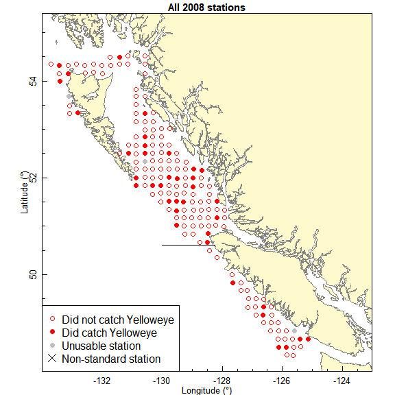

```r
plot_iphc_map(sp_set_counts$set_counts,
              sp_short_name = sp_short_name,
              years = 2008)
```

For the most recent year of data (see below for discussion):

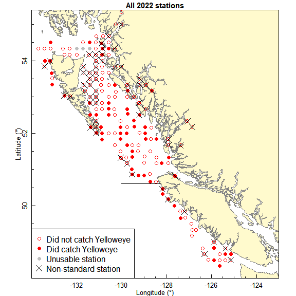

```r
plot_iphc_map(sp_set_counts$set_counts,
              sp_short_name = sp_short_name,
              years = max(sp_set_counts$set_counts$year))
```

For 2022 (and 2021) note that there is sporadic coverage off the west coast of Vancouver Island, with some of the usual stations being surveyed. In previous years it was all or nothing. This will affect the results of Series C and D (see README), and so whether or not the resulting Series AB can be considered representative for the whole coast. Series AB does not include the west coast of Vancouver Island. For 2022 there are also two stations (six in 2021) that were never previously fished and so we call these non-standard – see brief mention in the README and iphc-2021-data.pdf and iphc-2022-data.pdf for full details.

Unusable stations are determined by the IPHC and any data are excluded from our calculations. The horizontal line is the cut-off for calculations for different Series (see the synopsis Research Document). Note that the `sp_short_name` argument is only for the legend, the first argument needs to contain the data for the species of interest.

To see a movie of the station locations through time (a panel plot is shown shortly):

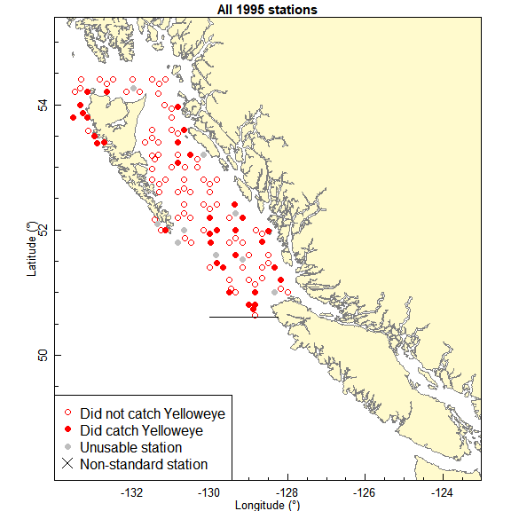

.

For reference, here is the code to build the movie, but it is commented out since it caused Travis (and now presumably GitHub Actions) to fail. Don’t worry about that. If you do want to make a different movie, run this vignette code with the next commented line uncommented (you need to install the `gifski` R package and the Gifski program), right-click on the animation in the html viewer and save it with the above filename (updated as appropriate).

````r
# ```{r, animation.hook = 'gifski', interval = 1.5, fig.height = 6}
for(i in unique(sp_set_counts$set_counts$year)){
  plot_iphc_map(sp_set_counts$set_counts,
                sp_short_name = sp_short_name,
                years = i)
}
````

A panel plot of all years is:

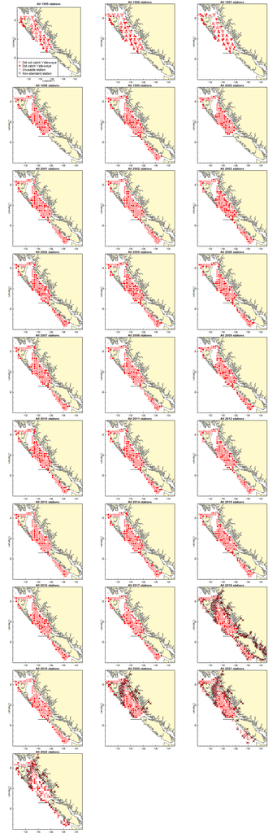

```r
years_to_plot <- unique(sp_set_counts$set_counts$year)
par(mfrow = c(ceiling(length(years_to_plot) / 3),
              3))

for(i in years_to_plot){
  plot_iphc_map(sp_set_counts$set_counts,
                sp_short_name = sp_short_name,
                years = i,
                mar_val =   c(1.8, 2, 2.0, 0.5),
                include_legend = (i == years_to_plot[1]) # only first panel
                )
}
```

For 2021, as mentioned above, there are six that were never fished before and we define as non-standard: five in the far north and one off the northwest tip of Vancouver Island (the latter would have been in a Rockfish Conservation Area according to the grid pattern). And for 2022 there are two close to the shore of northern Vancouver Island.

To see the stations without reference to any species (these are the 2008 stations, so think would be just the standard ones, can check code to confirm):

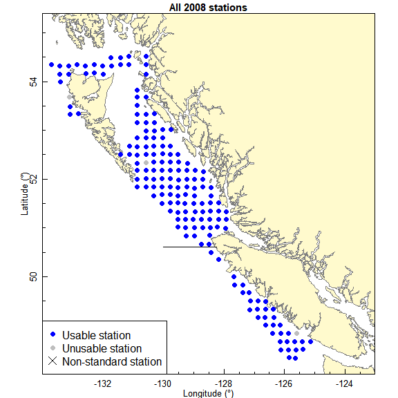

```r
plot_iphc_map(sp_set_counts$set_counts,
              sp = NULL,
              years = 2008)
```

noting that you still need `sp_set_counts$set_counts` (for an arbitrary species) as an argument.

Can also use `hooks_with_bait$set_counts` to see stations that came back with no bait (the legend will need adapting though; empty circles are no hook with bait returned):

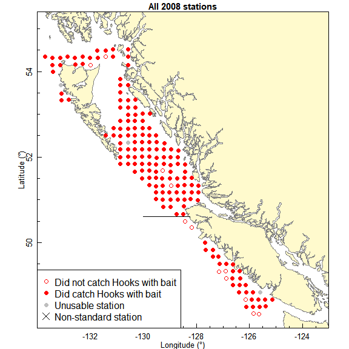

```r
plot_iphc_map(hooks_with_bait$set_counts,
              sp = "Hooks with bait",
              years = 2008)
```

## Expanded survey grid in 2018, 2020-2022

In the above movie and panel plot you see that the spatial coverage of sets changed in 2018, 2020-2022 due to the expanded survey grid that year that involved sets at extra stations:

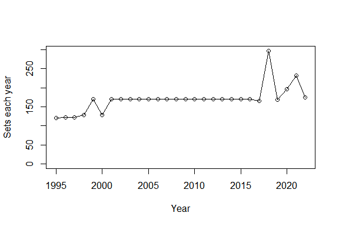

```r
sets_each_year <- sp_set_counts$set_counts %>%
  group_by(year) %>%
  summarise(total = n())

plot(sets_each_year$year, sets_each_year$total, type = "o",
     xlab = "Year", ylab = "Sets each year", ylim = c(0, max(sets_each_year$total)))
```

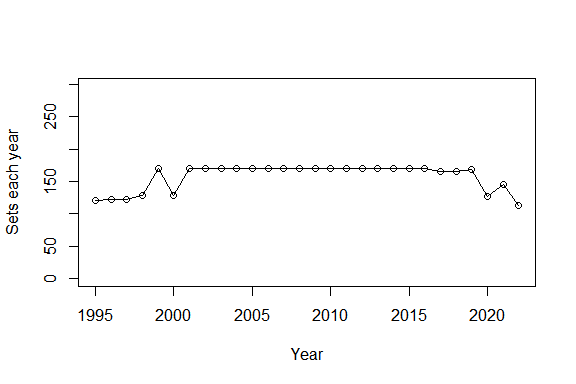

```r
sets_each_year_standard <- sp_set_counts$set_counts %>%
  filter(standard == "Y") %>%
  group_by(year) %>%
  summarise(total = n())

plot(sets_each_year_standard$year, sets_each_year_standard$total, type = "o",
     xlab = "Year", ylab = "Sets each year", ylim = c(0, max(sets_each_year$total)))
```

Except in recent years we have less stations after doing this, and 2022 is the lowest in the time series – spatiotemporal methods could be used to include the new non-standard stations (though also check the above .pdfs for mention of the original column that says that some stations should not be used for spatio-temporal analyses).

Note that the expansion (non-standard) stations only appear in recent years:

```r
filter(sp_set_counts$set_counts, standard == "N") %>%
  select(year) %>%
  unique()
```

```
#> # A tibble: 4 × 1
#>    year
#>   <dbl>
#> 1  2018
#> 2  2020
#> 3  2021
#> 4  2022
```

So we use `filter(..., standard == "Y", usable == "Y")` for upcoming analyses (to also include only the usable stations).

## Calculate longest time series possible for the full coast

In Appendix G of the synopsis report we described analyses to calculate as long a time series as possible by combining data from years when only the first 20 hooks were enumerated for each skate (Series A) with data from years when all hooks could be enumerated from each skate (Series B); there are overlapping years when all hooks were enumerated and the data are available at the hook-by-hook level. The resulting Series AB applies only to the area north of WCVI, but was tested to see if it was representative of the whole coast by also calculating Series C and D.

The function `calc_iphc_full_res()` does all the calculations in one step and saves all the output. See `?calc_iphc_full_res` for full details of the output, but basically `$ser_longest` is the longest time series that can be made for the species, with `$full_coast` indicating whether it can be considered representative of the full coast. Series A, B, C, and D are also given, along with geometric means and the test results comparing scaled series.

```r
series_ABCD_full <- calc_iphc_full_res(sp_set_counts$set_counts)
series_ABCD_full
```

```
#> $ser_longest
#> # A tibble: 28 × 8
#>     year  Sets num_pos20 I_t20SampleMean I_t20BootMean I_t20Bo…¹ I_t20…² I_t20…³
#>    <dbl> <int>     <int>           <dbl>         <dbl>     <dbl>   <dbl>   <dbl>
#>  1  1995   111        34           2.35          2.36      1.48     3.71   0.235
#>  2  1996   120        47           1.95          1.95      1.32     2.87   0.198
#>  3  1997   121        41           2.31          2.32      1.57     3.31   0.190
#>  4  1998   128        44           1.85          1.85      1.22     3.13   0.237
#>  5  1999   134        51           1.73          1.72      1.17     2.54   0.196
#>  6  2000   129        46           1.75          1.74      1.21     2.51   0.187
#>  7  2001   135        41           1.77          1.77      1.21     2.59   0.194
#>  8  2002   135        34           0.917         0.918     0.598    1.48   0.231
#>  9  2003   134        45           1.07          1.08      0.728    1.72   0.216
#> 10  2004   132        41           1.30          1.31      0.880    1.94   0.201
#> # … with 18 more rows, and abbreviated variable names ¹I_t20BootLow,
#> #   ²I_t20BootHigh, ³I_t20BootCV
#>
#> $type
#> [1] "AB"
#>
#> $full_coast
#> [1] TRUE
#>
#> $ser_all
#> $ser_all$ser_A
#> # A tibble: 26 × 8
#>     year  Sets num_pos20 I_t20SampleMean I_t20BootMean I_t20Bo…¹ I_t20…² I_t20…³
#>    <dbl> <int>     <int>           <dbl>         <dbl>     <dbl>   <dbl>   <dbl>
#>  1  1997   121        41           2.31          2.32      1.57     3.31   0.190
#>  2  1998   128        44           1.85          1.85      1.22     3.13   0.237
#>  3  1999   134        51           1.73          1.72      1.17     2.54   0.196
#>  4  2000   129        46           1.75          1.74      1.21     2.51   0.187
#>  5  2001   135        41           1.77          1.77      1.21     2.59   0.194
#>  6  2002   135        34           0.917         0.918     0.598    1.48   0.231
#>  7  2003   134        45           1.07          1.08      0.728    1.72   0.216
#>  8  2004   132        41           1.30          1.31      0.880    1.94   0.201
#>  9  2005   135        42           1.17          1.17      0.791    1.76   0.201
#> 10  2006   135        32           1.16          1.17      0.743    1.76   0.218
#> # … with 16 more rows, and abbreviated variable names ¹I_t20BootLow,
#> #   ²I_t20BootHigh, ³I_t20BootCV
```

[output cut: 117 more lines]

```
#> data:  ser_B_scaled$I_tBootMean and ser_C_scaled$I_tBootMean
#> t = 0.065115, df = 15, p-value = 0.9489
#> alternative hypothesis: true mean difference is not equal to 0
#> 95 percent confidence interval:
#>  -0.02163063  0.02299389
#> sample estimates:
#> mean difference
#>    0.0006816285
#>
#>
#> $test_BC$G_B
#> [1] 0.9908393
#>
#> $test_BC$G_C
#> [1] 0.8829123
```

Now plot Series A and B and show their scaled versions and the resulting Series AB (bottom right), which is the longest series available and is considered applicable to the whole coast if `series_ABCD_full$full_coast` is `TRUE`:

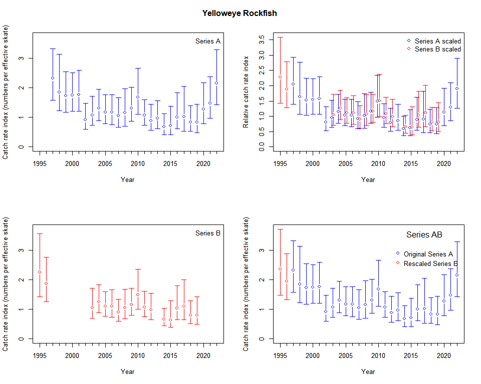

```r
plot_IPHC_ser_four_panels_ABCD(series_ABCD_full,
                               sp = sp)
```

```r
series_ABCD_full$type
```

```
#> [1] "AB"
```

```r
series_ABCD_full$full_coast
```

```
#> [1] TRUE
```

Recall there is a wrapper function, `iphc_get_calc_plot_full(sp)`, mentioned at the start of this vignette.

Note that the code may not yet fully account for all possibilities for the different Series, particularly for rarer species with, by definition, low count numbers. So do check that the output is sensible. The code may calculate a longest series, but it may not be ecologically useful. And a shorter series based on all years for which all hooks were counted (Series B) may be more useful than a longer one that uses only the first 20 hooks (Series A). In such cases maybe a Series BA could be implemented (use original Series B and then rescale Series A).